# Data Shapes

# Generating Patterns

## Sample

```r
sample(c("yes","no","maybe"), replace = TRUE, 10, prob=c(0.8,0.1,0.1))
```

```
##  [1] "no"  "yes" "yes" "yes" "yes" "yes" "yes" "yes" "yes" "yes"
```

```r
iris[sample(nrow(iris), 5), ] # 5 random observations from iris
```

```
##     Sepal.Length Sepal.Width Petal.Length Petal.Width    Species
## 147          6.3         2.5          5.0         1.9  virginica
## 143          5.8         2.7          5.1         1.9  virginica
## 33           5.2         4.1          1.5         0.1     setosa
## 64           6.1         2.9          4.7         1.4 versicolor
## 93           5.8         2.6          4.0         1.2 versicolor
```

## Sequence

```r
seq(along.with = 15:11) == seq_along(1:5) # 1 2 3 4 5
```

```
## [1] TRUE TRUE TRUE TRUE TRUE
```

```r
seq(4,11, length=20)
```

```
##  [1]  4.000000  4.368421  4.736842  5.105263  5.473684  5.842105  6.210526
##  [8]  6.578947  6.947368  7.315789  7.684211  8.052632  8.421053  8.789474
## [15]  9.157895  9.526316  9.894737 10.263158 10.631579 11.000000
```

```r
seq(4,11, by=3.2)
```

```
## [1]  4.0  7.2 10.4
```

We can also sequence along dates

```r
seq(as.Date("2000/1/1"), by = "month", length.out=12)
```

```
##  [1] "2000-01-01" "2000-02-01" "2000-03-01" "2000-04-01" "2000-05-01"
##  [6] "2000-06-01" "2000-07-01" "2000-08-01" "2000-09-01" "2000-10-01"
## [11] "2000-11-01" "2000-12-01"
```

## Replicate

```r
rep(c(1,2), times = 10) # 1 2 1 2 ...
```

```
##  [1] 1 2 1 2 1 2 1 2 1 2 1 2 1 2 1 2 1 2 1 2
```

```r
rep(c(1,2), each = 10) # 111..222...
```

```
##  [1] 1 1 1 1 1 1 1 1 1 1 2 2 2 2 2 2 2 2 2 2
```

# Generating Noise

## Distributions

R comes with operations for density/mass function, cumulative distribution function, quantile function, and random generation for a variety of distributions. These are named dxxx, pxxx, qxxx and rxxx respectively.

### Normal

We can specify means and sd for each individual number, or set a single value which is coerced into an appropriate length ie `rep(value, count)` for each number, otherwise by default `mean = 0` and `sd = 1`.

```r
rnorm(3) # 3 random variables
```

```
## [1]  0.2131575 -0.5466918 -0.4484630
```

```r
rnorm(3, c(1, 10, 100)) # specifying means
```

```
## [1]  1.848961 10.329262 99.000516
```

### Log-normal

### Binomial

### Multinomial

### Poisson

### Chi-squared

### Exponential

### Student’s t

### Uniform

### Others

Cauchy, geometric, hypergeometric, gamma, beta, F, negative binomial, Weibull.

> For less common distributions of test statistics see `pbirthday`, `dsignrank`, `ptukey` and `dwilcox` (and see the ‘See Also’ section of `cor.test`)

## By sampling

Sampling 100 elements randomly from a set containing 1000 rnorms and 1000 NAs.

```r
y <- rnorm(1000); z <- rep(NA,1000)
messy_data <- sample(c(y,z), 100)
my_na <- is.na(messy_data) # gives us a logical vector of where the NAs are
```

Since R represents TRUE as 1 and FALSE as 0, we can sum the TRUE and FALSE to get the total TRUEs:

```r
totalNAs <- sum(my_na); print(totalNAs)
```

```
## [1] 39
```

## jitter()

Using jitter to make a noisy sinewave

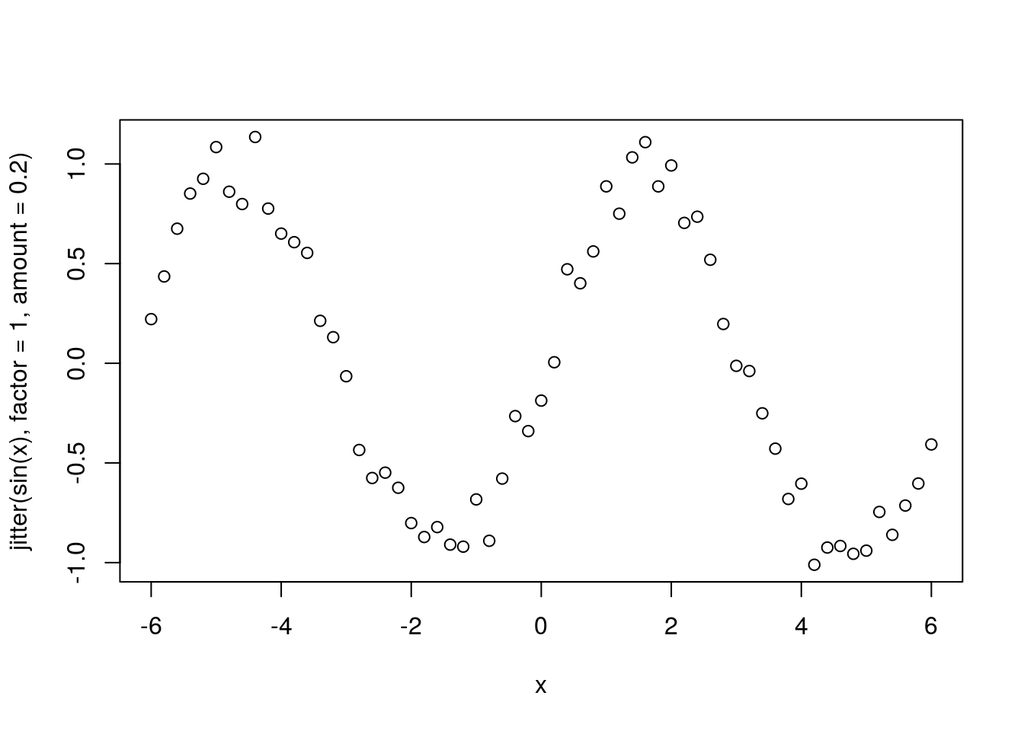

```r
x <- seq(-6, 6, by=0.2)
plot(x, jitter(sin(x), factor = 1, amount = 0.2))
```

# Data Manipulation

paste: sep, collapse see http://stackoverflow.com/questions/18475202/paste-collapse-in-r

subset, dplyr, tbl_df, paste, string stuff, regex

## Subsetting

### Extract

`[]` will always return an object of the same class as the original. It can be used to select more than one element.

`[[]]` is used to extract elems from a list or df. Can only extract one element (since elements could be of different classes) and the class of the returned object may not be the same as the original.

`$` is used to extract elems from a list or df by name. Similar semantics to `[[]]`.

```r
x <- list(numbers = 5:8, appletree = "a", age = 30)
class(x[1])
```

```
## [1] "list"
```

```r
class(x[[1]])
```

```
## [1] "integer"
```

```r
x$appletree
```

```
## [1] "a"
```

```r
identical(x$appletree, x[["appletree"]])
```

```
## [1] TRUE
```

```r
identical(x$appletree, x["appletree"])
```

```
## [1] FALSE
```

```r
x["appletree"]
```

```
## $appletree
## [1] "a"
```

Removing indices

```r
x <- 11:20
x[2:10]  # equivalent to `x[-1]`, "all but index 1"
```

```
## [1] 12 13 14 15 16 17 18 19 20
```

```r
x[c(-1,-5,-6)] # equivalent to x[-c(1,5,6)]
```

```
## [1] 12 13 14 17 18 19 20
```

Subsetting by name

```r
x <- list(a = "ok", b = 3.2, c = 11:14)
identical(x[[1]], x$a)
```

```
## [1] TRUE
```

```r
identical(x[[1]], x["a"])  # x["a"] == x$a
```

```
## [1] FALSE
```

Nested extraction with `[[]]`

```r
x <- list(a = "ok", b = 3.2, c = 11:14)
x[[c(3,2)]] # 2nd elem of the 3rd elem
```

```
## [1] 12
```

`[[]]` can be used with computed indices, `$` can only be used with literal names.

```r
x <- list(berries = 1:4, pennies = "a")
name <- "berries"
x[[name]]
```

```
## [1] 1 2 3 4
```

```r
x$name
```

Subsetting a matrix

```r
x <- matrix(1:6, 2, 3); print(x)
```

```
##      [,1] [,2] [,3]
## [1,]    1    3    5
## [2,]    2    4    6
```

```r
x[2,1]
```

```
## [1] 2
```

```r
x[1, ]  # first row
```

```
## [1] 1 3 5
```

```r
x[, 2]  # second column
```

```
## [1] 3 4
```

`[]` usually returns an object as the same type, but `x[2,1]` returned a vector, not a matrix by default. This can be turned off by setting `drop = FALSE`.

```r
x[2, , drop = FALSE]
```

```
##      [,1] [,2] [,3]
## [1,]    2    4    6
```

Partial Matching – seems more problematic than useful

```r
x <- list(lamp = 1:3, lantern = 18:14)
x$la
```

```r
x$lam
```

```
## [1] 1 2 3
```

```r
x[["lam"]]
```

```r
x[["lam", exact = FALSE]]
```

```
## [1] 1 2 3
```

### Logical

Logical index

```r
x <- 1:10
x[x > 6]
```

```
## [1]  7  8  9 10
```

Logical vector

```r
x <- 1:5
u <- x > 3 # F F F T T
x[u]
```

```
## [1] 4 5
```

Removing NAs by subsetting by a logical vector

```r
x <- c(1,2,NA,4,NA)
bad <- is.na(x)
x[!bad]
```

```
## [1] 1 2 4
```

We can use complete.cases to return a logical vector that tells us which indices of the objects *all* have no missing data

```r
y <- c(NA,2,3,4,NA)
good <- complete.cases(x,y); print(good)
```

```
## [1] FALSE  TRUE FALSE  TRUE FALSE
```

```r
x[good]
```

```
## [1] 2 4
```

```r
y[good]
```

```
## [1] 2 4
```

Using complete.cases on a data frame

```r
fac <- sample(LETTERS[1:3], 5, replace = TRUE)
d <- data.frame(x = 1:5, y = 6:10, fac = fac)
d[1,2] <- NA; d[2,3] <- NA
good <- complete.cases(d)
d[good, ]  # keep good rows only, keep all columns
```

```
##   x  y fac
## 3 3  8   A
## 4 4  9   C
## 5 5 10   A
```

### Factors

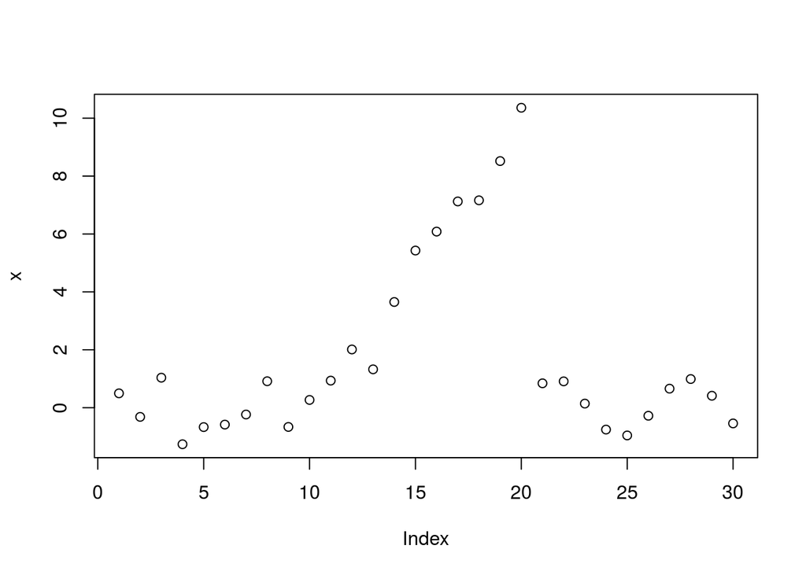

```r
library(ggplot2)
x <- c(rnorm(10), 1:10+rnorm(10), sin(1:10))
fac <- gl(3, 10, labels=c("normal", "linear", "sine"))
plot(x)
```

Splitting on a factor in a manner similar to `tapply`, we can divide a vector into subsets. and then overfit each subset with a 5th degree polynomial, just for fun.

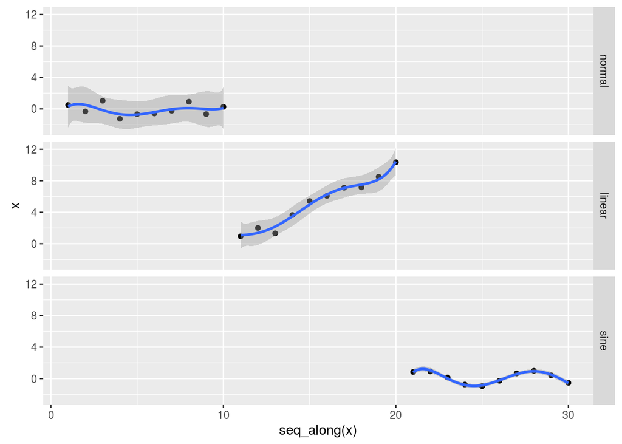

```r
y <- split(x,fac)
qplot(y=x, facets=fac ~ .) + geom_smooth(method="lm", formula = y ~ poly(x, 5))
```